# MiceData Analysis

Author

Asif Enan and Indranil Mukhopadhyay

## Load all the packages

```r
library(readxl)
library(tidyverse)
library(emmeans)
```

## **1st:** The first function `read_data_keyword`

Using the function I created in Task2 to read in the data. it essentially reads a raw gustometer xlsx by scanning for the row containing “PRESENTATION”, treating it as the header, and extracting only the valid data rows below it (stopping at the first fully empty row). handles the messy metadata info at the top.

```r
#General function to read the excel data into R
#Creating the function (has 3 parameters)

read_data_keyword <- function(file_path, keyword = "PRESENTATION", sheet = 1) {
  # Reading the entire sheet first
  raw_data <- read_excel(file_path, sheet = sheet, col_names = FALSE)

  # Identifying the starting row (where keyword is found)
  start_row <- which(apply(raw_data, 1, function(row) any(row == keyword)))[1]
  #defensive coding
  if (is.na(start_row)) {
    stop("Keyword not found in the sheet.")
  }

  # Extracting headers from the keyword row
  header_row <- as.character(unlist(raw_data[start_row, ]))

  # Finding the last non-empty column name
  last_col <- max(which(!(is.na(header_row) | header_row == "")))

  # Trimming the header and data columns to only valid headers
  headers <- header_row[1:last_col]

  # Getting all data rows starting from the next row after header row
  data_rows <- raw_data[(start_row + 1):nrow(raw_data), 1:last_col]

  # Finding first empty row (all cells are NA or "")
  end_row_relative <- which(apply(data_rows, 1, function(row) all(is.na(row) | row == "")))[1]

  if (!is.na(end_row_relative)) {
    # Limit to rows before the empty one
    data_rows <- data_rows[1:(end_row_relative - 1), ]
  }

  # Set column names
  colnames(data_rows) <- headers

  return(data_rows)
}
```

## **2nd:** Function for reading the excel files

This function runs the above function, `read_data_keyword` on every `.xlsx` in a folder and returns a named list, one element per file. This let you load all mice gustometer data files at once.

```r
import_all_xlsx_files <- function(folder_path, keyword = "PRESENTATION") {
  files <- list.files(path = folder_path, pattern = "\\.xlsx$", full.names = TRUE)

  # Applying cleaning function to each file and storing in a named list
  data_list <- lapply(files, function(file) {
    tryCatch({
      read_data_keyword(file, keyword = keyword)
    }, error = function(e) {
      warning(paste("Skipping file:", file, "-", e$message))
      NULL
    })
  })

  # Naming each element by filename
  names(data_list) <- basename(files)

  return(data_list)
}
```

Be mindful that the output of the above function generates a list (a named list of dataframes as its elements)

## What the above 2 function does

- `read_data_keyword` : takes a **single file path**, finds the keyword row, extracts clean data, returns one dataframe.
- `import_all_xlsx_files` : takes a **folder path**, finds all `.xlsx` files in it, loops through them calling `read_data_keyword` on each, returns a named list of dataframes.

## Trying out the function

Firstly, this is what my folder looks like since I do not have all the data. The files reside inside of my working directory, specifically in the mice sub-folder of the data folder `data/mice`

[figure not shown]

```r
mice_datalist<-import_all_xlsx_files("data/mice", keyword = "PRESENTATION")
```

All of the cleaned mice data is now stored in the named list called `mice_datalist`.

```r
class(mice_datalist)
```

```
[1] "list"
```

```r
names(mice_datalist)
```

```
[1] "0714A645.ms8.xlsx" "0719A519.ms8.xlsx" "0719A579.ms8.xlsx"
[4] "0719A584.ms8.xlsx" "0719A650.ms8.xlsx" "0719A653.ms8.xlsx"
[7] "0719A656.ms8.xlsx"
```

Now, the information that I was given was that

0719A656.ms8, 0719A653.ms8, 0719A650.ms8, 0719A584.ms8: **belongs to WT genotype**

0719A579.ms8, 0719A519.ms8, 0714A645.ms8: **belongs to CKO genotype**

So I will subset the combined list into 2 lists:

```r
mice_datalist_WT  <- mice_datalist[c(4, 5, 6, 7)]
mice_datalist_CKO <- mice_datalist[c(1, 2, 3)]
```

You do not have to necessarily do this if you have a folder of data separated by the genotype. There, you just run the `import_all_xlsx_files()` function on those two folders.

## **3rd:** Function for Calculating the LickRatio

The key metric is the **Lick Ratio**:

> **Lick Ratio = Licks to taste compound ÷ Licks to water**

We’ll be constructing a function that does this, but also keeping some other conditions in mind. In the function we will follow these steps.

**Step 1: Check licks for water first** (since it’s the denominator): Look at the raw lick vector for `0mM`. If fewer than 2 trials have non-zero licks → **drop the entire mouse**. No point going further.

**Step 2: Check licks of the other concentrations** (`30mM`, `1mM`, `3mM`, `10mM`): For each concentration, we will look at the raw lick vector and apply this rule:

- **If 2 or more trials have non-zero licks** → keep. (e.g. `[1, 0, 0, 1, 0, 0]`)
- **If only 1 trial has non-zero licks, BUT that single value is ≥ 10** → also keep. (e.g. `[15, 0, 0, 0, 0, 0]` passes, `[9, 0, 0, 0, 0, 0]` does not)
- **If only 1 trial has non-zero licks AND that value is < 10** → **drop the entire mouse**.
- **If zero trials have non-zero licks** → **drop the entire mouse**.

And in all “drop” cases, we’re removing the **whole mouse**, not just that concentration.

```r
get_lick_ratios <- function(data, mouse_id=1, genotype_label= "No genotype specified") {

  # Ensuring LICKS is numeric up front
  data <- data %>% mutate(LICKS = as.numeric(LICKS),
                          CONCENTRATION = trimws(as.character(CONCENTRATION))
                          )

  #Step 1: Raw lick vector for Water
  water_trials <- data %>%
    filter(CONCENTRATION %in% c("0", "0mM")) %>%
    pull(LICKS)

  n_nonzero_water <- sum(water_trials > 0, na.rm = TRUE)

  if (n_nonzero_water < 2) {
    message(paste("Mouse", mouse_id, "(", genotype_label, ") excluded: fewer than 2 non-zero water trials."))
    return(NULL)
  }

  #Step 2: Raw lick vector for non-water concentrations
  taste_concs <- data %>%
    filter(!CONCENTRATION %in% c("0", "0mM")) %>%
    pull(CONCENTRATION) %>%
    unique()

  for (conc in taste_concs) {
    conc_trials <- data %>%
      filter(CONCENTRATION == conc) %>%
      pull(LICKS)
   #we keep only the values that are both non-NA and greater than zero
    nonzero_vals  <- conc_trials[!is.na(conc_trials) & conc_trials > 0]
    n_nonzero     <- length(nonzero_vals)

    exclude <- FALSE

    if (n_nonzero == 0) {
      # No licking at all at this concentration
      exclude <- TRUE
    } else if (n_nonzero == 1) {
      # Only one non-zero trial: keep only if that single value >= 10
      if (nonzero_vals[1] < 10) {
        exclude <- TRUE
      }
    }
    # n_nonzero >= 2: always keep, no action needed

    if (exclude) {
      message(paste("Mouse", mouse_id, "(", genotype_label, ") excluded: concentration", conc,
                    "failed the reliability check (non-zero trials:", n_nonzero,
                    "| values:", paste(nonzero_vals, collapse = ", "), ")."))
      return(NULL)
    }
  }

  # Once a mouse passed all checks: compute LickRatio
  data %>%
    group_by(CONCENTRATION) %>%
    summarise(total_licks = sum(LICKS, na.rm = TRUE), .groups = "drop") %>%
    mutate(
      CONCENTRATION = as.character(CONCENTRATION),
      water_licks   = total_licks[CONCENTRATION %in% c("0", "0mM")],
      # water_licks is guaranteed > 0 by Step 1, so LickRatio will never be Inf or NaN
      LickRatio     = total_licks / water_licks,
      CONCENTRATION = as.factor(CONCENTRATION)
    ) %>%
    filter(CONCENTRATION %in% c("1mM", "3mM", "10mM", "30mM")) %>%
    mutate(Mouse = mouse_id, Genotype = genotype_label)
}
```

Now let us try this function on the earlier data list we imported. Recall, we had it named `mice_datalist`, then from that we created further 2 lists based on the genotype `mice_datalist_WT` and `mice_datalist_CKO`

```r
get_lick_ratios(mice_datalist_WT[["0719A584.ms8.xlsx"]],mouse_id = 1,genotype_label = "WT")
```

```
# A tibble: 4 × 6
  CONCENTRATION total_licks water_licks LickRatio Mouse Genotype
  <fct>               <dbl>       <dbl>     <dbl> <dbl> <chr>
1 10mM                   66           7      9.43     1 WT
2 1mM                    28           7      4        1 WT
3 30mM                   81           7     11.6      1 WT
4 3mM                    29           7      4.14     1 WT
```

Now, we will try this in a dataset where it does not fulfill one of the conditions

```r
get_lick_ratios(mice_datalist_WT[["0719A650.ms8.xlsx"]],mouse_id = 1,genotype_label = "WT")
```

```
Mouse 1 ( WT ) excluded: fewer than 2 non-zero water trials.
```

The function I created, nicely mentions what went wrong in this dataset, and that it contains fewer than 2 non-zero water trials. Let us verify this in excel.

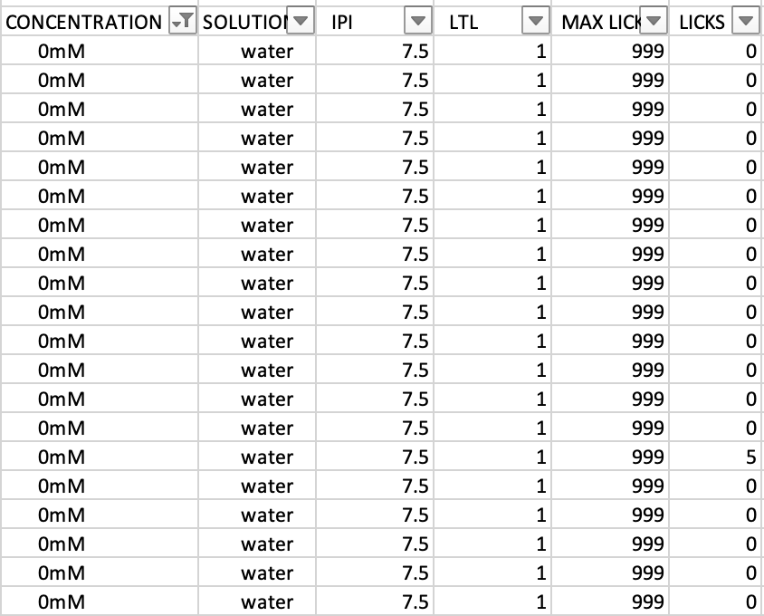

Screenshot from Excel

So, for this dataset we see that there is only one instant of lick, and that is in the value of 5.

We will try another instance where one of the other concentrations Does not fulfill the condition.

```r
get_lick_ratios(mice_datalist_CKO[["0714A645.ms8.xlsx"]])
```

```
Mouse 1 ( No genotype specified ) excluded: concentration 3mM failed the reliability check (non-zero trials: 1 | values: 2 ).
```

Here, the functions mentions that the concentration 3mM does not fulfill the condition. Let us again verify with excel file.

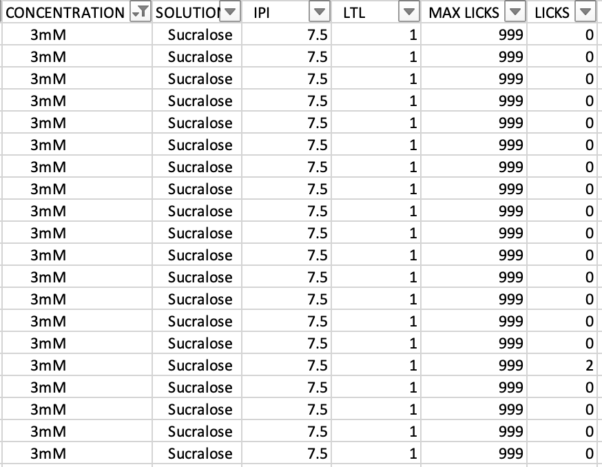

Again, we can see that the licks column only contains one non-zero value, which is two, so the function works.

## **4th:** Using the `get_lick_ratios()` function on many datasets using `map2()`

Now, Applying the get_licks_ratios() function, on one data frame at a time is inefficient, and if we have 100 or more than 100 data sets, it will take a lot of time.

We need to find a way to apply this function to many data sets in one go. That is what the code will do. a way of applying a function to every element of a list, one at a time, without writing a for loop.

Recall, we had a combined list named `mice_datalist`, then from that we created further 2 lists based on the genotype `mice_datalist_WT` and `mice_datalist_CKO`. (We can have more than 2 genotype as well)

```r
class(mice_datalist_CKO)
```

```
[1] "list"
```

```r
length(mice_datalist_CKO)
```

```
[1] 3
```

```r
class(mice_datalist_WT)
```

```
[1] "list"
```

```r
length(mice_datalist_WT)
```

```
[1] 4
```

#### **Step 1:**

Since we already have a combined `mice_datalist`, we will use that for this function. But if all our lists were separated by genotypes, say, we had `mice_datalist_CKO` , `mice_datalist_WT` and `mice_datalist_RB`. We would combine them into a single list using.

```r
# datasets <- c(mice_datalist_CKO, mice_datalist_WT, mice_datalist_RB )
```

The order of combining matters, so need to be kept in mind. Since the genotypes vector below will follow the same order. For us we will use

```r
datasets <- c(mice_datalist_WT, mice_datalist_CKO)
```

#### **Step 2:**

Build the genotype label vector to match that order.

```r
genotypes <- c(
  rep("WT",  length(mice_datalist_WT)),
  rep("CKO", length(mice_datalist_CKO))
)
```

Notice first we put WT and then CKO.

#### **Step 3:**

Build sequential mouse IDs. Here we will use the `mouse_ids` to be the name of the excel files, so that any issues can be tracked back to the excel sheet.

```r
mouse_ids <- tools::file_path_sans_ext(names(datasets))
```

#### **Step 4:**

Apply get_lick_ratios to every mouse in one pass `map2` pairs each dataframe with its position index, from that index we look up the right genotype and mouse_id

```r
results_list <- map2(
  .x = datasets,          # the dataframe for this mouse
  .y = seq_along(datasets), # its position: 1, 2, 3, ... 200
  .f = ~ get_lick_ratios(
    data           = .x,
    mouse_id       = mouse_ids[.y],
    genotype_label = genotypes[.y]
  )
)
```

```
Mouse 0719A650.ms8 ( WT ) excluded: fewer than 2 non-zero water trials.
```

```
Mouse 0714A645.ms8 ( CKO ) excluded: concentration 3mM failed the reliability check (non-zero trials: 1 | values: 2 ).
```

The above code will execute the function `get_lick_ratios()` across all the datasets. But it outputs a list object. So, `results_list` object is a list. let us verify

```r
class(results_list)
```

```
[1] "list"
```

You can view this list from the environment tab as well, where you will see this:

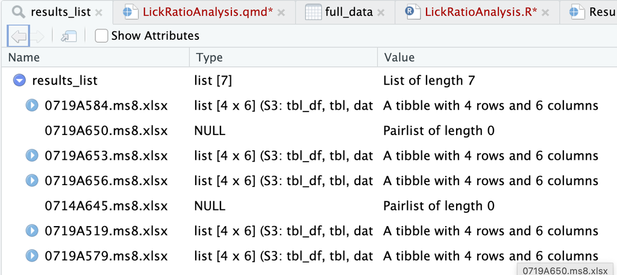

Each element of this list is either a:

- small dataframe (mouse passed, and then the lick ratio is calculated) or
- NULL (mouse was excluded by get_lick_ratios because it failed one of the conditions)

#### **Step 5:**

Collapse all the dataframes inside of that list into one combined dataframe and also get rid of those NULL dataframes (Which are mice that did not pass one of the conditions)

```r
all_lick_ratios <- list_rbind(results_list)
```

`all_lick_ratios` is now one tidy dataframe ready for modeling, where

- each rows = one concentration per mouse that passed and
- columns = CONCENTRATION, total_licks, LickRatio, Mouse, Genotype

Looking at the dataframe:

```r
head(all_lick_ratios)
```

```
# A tibble: 6 × 6
  CONCENTRATION total_licks water_licks LickRatio Mouse        Genotype
  <fct>               <dbl>       <dbl>     <dbl> <chr>        <chr>
1 10mM                   66           7      9.43 0719A584.ms8 WT
2 1mM                    28           7      4    0719A584.ms8 WT
3 30mM                   81           7     11.6  0719A584.ms8 WT
4 3mM                    29           7      4.14 0719A584.ms8 WT
5 10mM                   42          14      3    0719A653.ms8 WT
6 1mM                    21          14      1.5  0719A653.ms8 WT
```

#### **Step 6:**

Factor the concentration column for ordered modeling

```r
all_lick_ratios <- all_lick_ratios %>%
  mutate(CONCENTRATION = factor(CONCENTRATION,
                                levels = c("1mM", "3mM", "10mM", "30mM"),
                                ordered = TRUE))
```

## **5th:** Modeling

Firstly fitting a two-way ANOVA model:

Then using `emmeans` to compute estimated marginal means and run **pairwise post-hoc contrasts** (WT vs. SpibKO at each concentration), corrected with Tukey’s adjustment. [Steps followed from: https://journals.plos.org/plosbiology/article?id=10.1371/journal.pbio.3001647 ]

```r
Sucralose.lm <- lm(LickRatio ~ Genotype * CONCENTRATION, data = all_lick_ratios)
```

```r
joint_tests(Sucralose.lm)
```

```
 model term             df1 df2 F.ratio p.value
 Genotype                 1  12   0.630  0.4429
 CONCENTRATION            3  12   1.681  0.2239
 Genotype:CONCENTRATION   3  12   0.397  0.7579
```

```r
Sucralose.emm<-emmeans(Sucralose.lm,~Genotype*CONCENTRATION)
Sucralose.emm
```

```
 Genotype CONCENTRATION emmean   SE df lower.CL upper.CL
 CKO      1mM             1.76 2.18 12   -2.988     6.50
 WT       1mM             1.98 1.78 12   -1.894     5.86
 CKO      3mM             4.98 2.18 12    0.235     9.73
 WT       3mM             4.15 1.78 12    0.276     8.03
 CKO      10mM            4.48 2.18 12   -0.265     9.23
 WT       10mM            6.38 1.78 12    2.508    10.26
 CKO      30mM            4.39 2.18 12   -0.352     9.14
 WT       30mM            7.56 1.78 12    3.686    11.44

Confidence level used: 0.95
```

```r
contrast(Sucralose.emm,"pairwise",simple="each",adjust="tukey")
```

```
$`simple contrasts for Genotype`
CONCENTRATION = 1mM:
 contrast estimate   SE df t.ratio p.value
 CKO - WT   -0.223 2.81 12  -0.079  0.9380

CONCENTRATION = 3mM:
 contrast estimate   SE df t.ratio p.value
 CKO - WT    0.830 2.81 12   0.295  0.7729

CONCENTRATION = 10mM:
 contrast estimate   SE df t.ratio p.value
 CKO - WT   -1.903 2.81 12  -0.677  0.5115

CONCENTRATION = 30mM:
 contrast estimate   SE df t.ratio p.value
 CKO - WT   -3.167 2.81 12  -1.126  0.2821


$`simple contrasts for CONCENTRATION`
Genotype = CKO:
 contrast    estimate   SE df t.ratio p.value
 1mM - 3mM     -3.223 3.08 12  -1.046  0.7268
 1mM - 10mM    -2.723 3.08 12  -0.884  0.8132
 1mM - 30mM    -2.636 3.08 12  -0.856  0.8271
 3mM - 10mM     0.500 3.08 12   0.162  0.9984
 3mM - 30mM     0.587 3.08 12   0.191  0.9974
 10mM - 30mM    0.087 3.08 12   0.028  1.0000

Genotype = WT:
 contrast    estimate   SE df t.ratio p.value
 1mM - 3mM     -2.169 2.52 12  -0.862  0.8238
 1mM - 10mM    -4.402 2.52 12  -1.750  0.3420
 1mM - 30mM    -5.579 2.52 12  -2.218  0.1735
 3mM - 10mM    -2.233 2.52 12  -0.888  0.8113
 3mM - 30mM    -3.410 2.52 12  -1.356  0.5479
 10mM - 30mM   -1.177 2.52 12  -0.468  0.9647

P value adjustment: tukey method for comparing a family of 4 estimates
```